# Parte 3

Erick Emiliano Aduna Camilo

19/3/2022

## Red de señalización, Parte 3

Para esta parte tomaremos la representaci+on de una red de señalización, formada en base a la información de estos dos artículos

Li S, Assmann SM, Albert R. Predicting essential components of signal transduction networks: a dynamic model of guard cell abscisic acid signaling. PLoS Biol 2006;4:e31

Saadatpour A, Albert I, Albert R. Attractor analysis of asynchronous Boolean models of signal transduction networks. J Theor Biol 2010;4:641–56.

Las posibles reglas de la red son estas:

CIS, cGMP & cADPR & InsP3 cGMP, GC cADPR, ADPRc InsP3,PLC GC, NO ADPRc, NO NO, NOS NOS,CA2 PLC,CA2 CA2, CaIM & CIS & !CA2ATP CaIM, !Depolar CA2ATP, CA2 KEV, CA2 HATP, !CA2 AnionEM, CA2 Clousure, AnionEM &KOUT & KAP KOUT, Depolar KAP,Depolar Depolar, KEV&!HATP & !KOUT& AnionEM

Ahora hacemos el modelo en base a el esquema de los artículos,con ayuda del paquete BoolNet

el archivo de texto plano con la reglas esta igualmente anexado en la carpeta de “Datos” del R project

```r
library(BoolNet)
```

```r
red_senalizacion <- loadNetwork("Datos/Red de senalizacion.txt")

red_senalizacion
```

```
## Boolean network with 19 genes
##
## Involved genes:
## CIS cGMP cADPR InsP3 GC ADPRc NO NOS PLC CA2 CaIM CA2ATP KEV HATP AnionEM Clousure KOUT KAP Depolar
##
## Transition functions:
## CIS = cGMP & cADPR & InsP3
## cGMP = GC
## cADPR = ADPRc
## InsP3 = PLC
## GC = NO
## ADPRc = NO
## NO = NOS
## NOS = CA2
## PLC = CA2
## CA2 = CaIM & CIS & !CA2ATP
## CaIM = !Depolar
## CA2ATP = CA2
## KEV = CA2
## HATP = !CA2
## AnionEM = CA2
## Clousure = AnionEM & KOUT & KAP
## KOUT = Depolar
## KAP = Depolar
## Depolar = KEV &!HATP & !KOUT & AnionEM
```

Con la red ya cargada podemos hacer analisis y dar importancia biológica a los atractores resultantes.

Ploteamos la red para visualizarla

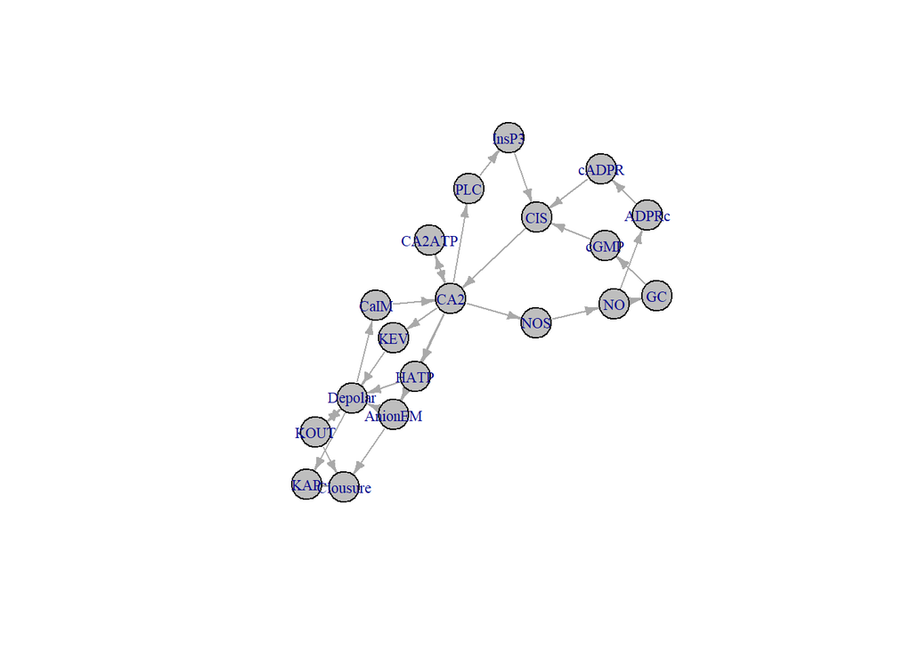

```r
plotNetworkWiring(red_senalizacion)
```

Obtenemos los atractores de la red

```r
satractors <-  getAttractors(red_senalizacion)

satractors
```

```
## Attractor 1 is a simple attractor consisting of 1 state(s) and has a basin of 524288 state(s):
##
##  |--<------------------|
##  V                     |
##  0000000000100100000   |
##  V                     |
##  |-->------------------|
##
##
## Genes are encoded in the following order: CIS cGMP cADPR InsP3 GC ADPRc NO NOS PLC CA2 CaIM CA2ATP KEV HATP AnionEM Clousure KOUT KAP Depolar
```

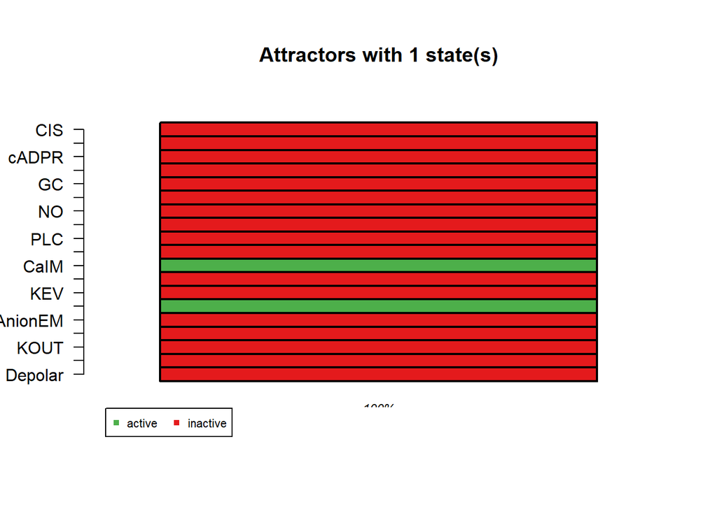

```
## $`1`
##          Attr1.1
## CIS            0
## cGMP           0
## cADPR          0
## InsP3          0
## GC             0
## ADPRc          0
## NO             0
## NOS            0
## PLC            0
## CA2            0
## CaIM           1
## CA2ATP         0
## KEV            0
## HATP           1
## AnionEM        0
## Clousure       0
## KOUT           0
## KAP            0
## Depolar        0
```

```r
plotAttractors(satractors)
```

```r
red_senalizacion_1 <- loadNetwork("Datos/Red de senalizacion1.txt")

red_senalizacion_1
```

```
## Boolean network with 19 genes
##
## Involved genes:
## CIS cGMP cADPR InsP3 GC ADPRc NO NOS PLC CA2 CaIM CA2ATP KEV HATP AnionEM Clousure KOUT KAP Depolar
##
## Transition functions:
## CIS = cGMP | cADPR | InsP3
## cGMP = GC
## cADPR = ADPRc
## InsP3 = PLC
## GC = NO
## ADPRc = NO
## NO = NOS
## NOS = CA2
## PLC = CA2
## CA2 = CaIM | CIS & !CA2ATP
## CaIM = !Depolar
## CA2ATP = CA2
## KEV = CA2
## HATP = !CA2
## AnionEM = CA2
## Clousure = AnionEM | KOUT | KAP
## KOUT = Depolar
## KAP = Depolar
## Depolar = KEV &!HATP & !KOUT | AnionEM
```

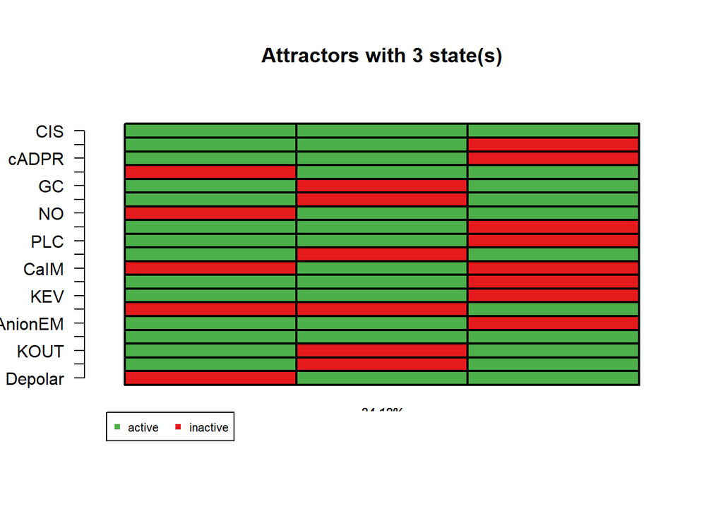

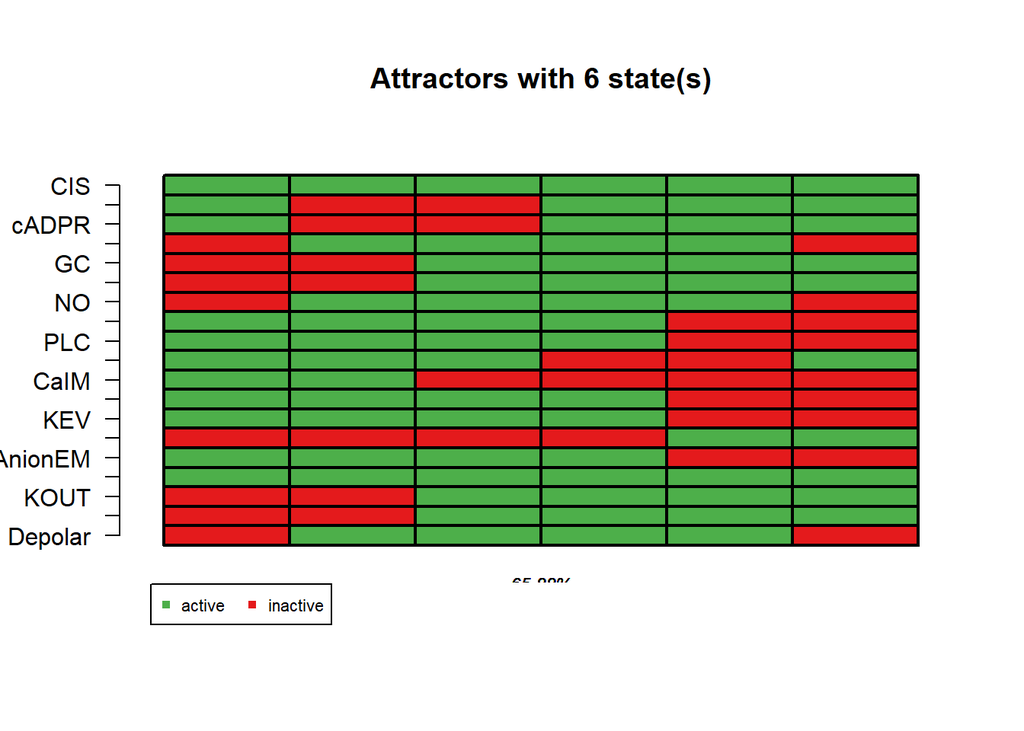

```
## $`3`
##          Attr1.1 Attr1.2 Attr1.3
## CIS            1       1       1
## cGMP           1       1       0
## cADPR          1       1       0
## InsP3          0       1       1
## GC             1       0       1
## ADPRc          1       0       1
## NO             0       1       1
## NOS            1       1       0
## PLC            1       1       0
## CA2            1       0       1
## CaIM           0       1       0
## CA2ATP         1       1       0
## KEV            1       1       0
## HATP           0       0       1
## AnionEM        1       1       0
## Clousure       1       1       1
## KOUT           1       0       1
## KAP            1       0       1
## Depolar        0       1       1
##
## $`6`
##          Attr2.1 Attr2.2 Attr2.3 Attr2.4 Attr2.5 Attr2.6
## CIS            1       1       1       1       1       1
## cGMP           1       0       0       1       1       1
## cADPR          1       0       0       1       1       1
## InsP3          0       1       1       1       1       0
## GC             0       0       1       1       1       1
## ADPRc          0       0       1       1       1       1
## NO             0       1       1       1       1       0
## NOS            1       1       1       1       0       0
## PLC            1       1       1       1       0       0
## CA2            1       1       1       0       0       1
## CaIM           1       1       0       0       0       0
## CA2ATP         1       1       1       1       0       0
## KEV            1       1       1       1       0       0
## HATP           0       0       0       0       1       1
## AnionEM        1       1       1       1       0       0
## Clousure       1       1       1       1       1       1
## KOUT           0       0       1       1       1       1
## KAP            0       0       1       1       1       1
## Depolar        0       1       1       1       1       0
```

```r
satractors_1 <- getAttractors(red_senalizacion_1)

plotAttractors(satractors_1)
```

Repitiendo los mismos pasos encontramos ahora dos atractores, pero ahora son ciclicos, por lo que este tipo de atractores tiene más sentido que al inicio, si bien puede parecer obvio como aplicar las reglas, con este ejemplo me di cuenta que no es tan sencillo al inicio.

Continuando con los atractores para el segundo caso,como se menciono se obtienen dos atractores ciclicos y un punto importante a destacar es que CIS siempre se encuantra activo, tiene sentido debido a que cuenta con 3 activadores y para este ejemplo usamos el condicional OR, por lo que no es necesario que los 3 lo activen simultaneamente. Revisando los articulos en los que esta basado el modelo, vemos que CIS tiene funciones de transporte de membrana, por lo que puede tener sentido que siempre este activo, simplemente cambia la molécula por la que es activada y en estricto sentido que transportaría, revisando algunos artículos extras se menciona la luz y la dirección de esta “Cis”. El resto de elementos son otras enzimas y o transportadores, por lo que es una vía compleja.